# Rubric

## Data

### Data overview

#### MTA Subway Hourly Ridership (2023)

- Dataset Name: MTA Subway Hourly Ridership: 2020-2024
- Link to the dataset: ([https://data.ny.gov/Transportation/MTA-Subway-Hourly-Ridership-2020-2024/wujg-7c2s/about_data])
- Number of observations: 121 Million
- Number of variables: 12
- Description of the variables most relevant to this project:
  - transit_timestamp - The date and time in which the payment took place, rounded to the nearest hour
  - transit_mode - Distinguishes between the subway, Staten Island Railway, and the Roosevelt Island Tram. We will be using only the subway
  - station_complex - The subway complex where an entry swipe or tap took place. Large subway complexes, such as Times Square and Fulton Center, may contain multiple subway lines. The subway complex name includes the routes that stop at the complex in parenthesis, such as Zerega Av (6).
  - ridership - Total number of riders that entered a subway complex via OMNY or MetroCard at the specific hour and for that specific fare type.
  - latitude - Latitude for the specified subway complex
  - longitude - Longitude for the specified subway complex
- Descriptions of any shortcomings this dataset has with respect to the project:
  - The dataset is massive and will take some clever querying and processing to make it manageable.

#### Ride Hailing Dataset

- Dataset Name: High Value For Hire Vehicle Data
- Link to the dataset: ([https://data.cityofnewyork.us/Transportation/2023-High-Volume-FHV-Trip-Data/u253-aew4/about_data])
- Number of observations: 707211
- Number of variables: 14
- Description of the variables most relevant to this project:
  - pickup_datetime - Pickup date and time (M/D/Y H:M:S)
  - PULocationID - Pickup location taxi zone ID
  - base_passenger_fare - base passenger fare before tolls, tips, taxes, and fees
  - tolls - total amount of tolls paid in trip
  - bcf - total amount collected in trip for black car fund
  - sales_tax - total amount collected in trip for NYS sales tax
  - congestion_surcharge - total amount collected in trip for NYS congestion surcharge
  - airport_fee -$2.50 for both drop off and pick up at LaGuardia, Newark, and John F. Kennedy airports
  - tips - total amount of tips received from passenger
- Descriptions of any shortcomings this dataset has with respect to the project:
  - This dataset's biggest shortcomings is its overachieving. It's quite literally every ride in New York on this day, so we need to compress the data greatly.

#### Weather Dataset

- Dataset Name: NOAA NYC Daily Weather Summaries
- Link to the dataset: ([https://www.ncdc.noaa.gov/cdo-web/datasets/GHCND/locations/CITY:US360019/detail])
- Number of observations: 33284
- Number of variables: 23
- Description of the variables most relevant to this project:
  - NAME - The name and abbreviated address of the weather station
  - DATE - Date in which an observation was made
  - PRCP (Precipitation) - Floating point value of the quantity of rain in inches
  - SNOW - Floating point value of the quantity of snowfall in inches
  - SNWD - Floating point value of the quantity of snow depth in inches
  - TAVG - Average temperature in degrees fahrenheit
  - TMAX - Maximum temperature in degrees fahrenheit
  - TMIN - Minimum temperature in degrees fahrenheit
- Descriptions of any shortcomings this dataset has with respect to the project:
  - Not all stations have all of the necessary weather variables (TMAX, TMIN, TAVG, PRCP, SNOW).
  - Some stations are missing a few days (~10-12) days of the year.

#### Gas Price Dataset

- Dataset Name:Weekly New York City Regular All Formulations Retail Gasoline Prices
- Link to the dataset: ([https://www.eia.gov/dnav/pet/hist/LeafHandler.ashx?n=PET&s=EMM_EPMR_PTE_Y35NY_DPG&f=W])
- Number of observations: 1346
- Number of variables: 2
- Description of the variables most relevant to this project:
  - Date - The date that the gas price was recorded
  - Weekly New York City Regular All Formulations Retail Gasoline Prices (Dollars per Gallon) - Prices of regular gas in New York
- Descriptions of any shortcomings this dataset has with respect to the project:
  - Data is weekly, not daily.
  - City wide average of gas price, gas prices could vary by neighborhood.

### MTA Subway Hourly Ridership (2023)

The main variable that we are interested in is ridership, which is the total number of riders that entered a subway recorded through the New York City payment system card. This ridership value includes transfers, those who use a free bus-to-subway or free out-of-network transportation. For example, Time Square station complexes could get thousands of entries while outskirts complexes could get significantly less. The MTA Subway Hourly Ridership would allow us to see the times of peak ridership along with the lows of ridership.

One of the biggest concerns we have is the massive size of the datasets that we will be handling. To manage this we chose to use the "Query data" action on the website to reduce the dataset to the year 2023 and the specific variables we need. This resulted in a 3 GB CSV file which we processed locally to further reduce the size before adding the dataset to our Github repo.

Another concern is with ridership counts. Due to the ridership counts being counted based on fare payment transactions, those who evade subway fare will not be counted. So systemically, the ridership number will be underreported. MTA reports that subway fare evasion is around 10% which has decreased from the year before (https://cbcny.org/research/no-fare). Due to the volatile rate of fare evasion, it may bias the trend.

### Note:

The following ingestion and data wrangling is to demonstrate the procedure and is done on a 10,000 row subset of the full 2023 MTA dataset. The final output of the MTA dataset we are using in our project is "MTA_Subway_Daily_Manhattan.csv".

## Setup

This notebook should be run from the project root directory: `Group063_WI26`.

### 1. Create a virtual environment

We recommend creating a fresh virtual environment before installing dependencies.

Using `venv`:

```
python3 -m venv .venv
source .venv/bin/activate # On Windows, use: .venv\Scripts\activate
```

or in Windows

```
python3 -m venv .venv
.venv/Scripts/activate
```

### 2. Install dependencies

```
pip install -r requirements.txt
```

### 3. Select the correct Python kernel in Jupyter

```python
from modules.run_imports import setup_final_project_imports

setup_final_project_imports(globals())
```

[output not shown]

[output cut: 229 more lines]

```python
import pandas as pd
MTA_hrly_23 = pd.read_csv("data/00-raw/MTA_Subway_Hourly_Ridership__2020-2024_20260222_DEMO.csv")
print("The total number of missing values:", MTA_hrly_23.isna().sum().sum())
print('The only transit mode in our dataset is: ', MTA_hrly_23.transit_mode.unique())
# And, focusing specifically on the Manhattan borough...
mnhtn_MTA_hrly_23 = MTA_hrly_23.loc[MTA_hrly_23['borough'] == 'Manhattan'].copy()
print('The only borough in our dataset is: ', mnhtn_MTA_hrly_23.borough.unique())
# Therefore we can drop the borough and transit_mode columns.
mnhtn_MTA_hrly_23 = mnhtn_MTA_hrly_23.drop(['transit_mode','borough'], axis = 1)
# Next, we can create a map of the station_complex_ids and the station_complexes to reduce the size of our dataframe.
mnhtn_MTA_hrly_23['station_complex'] = mnhtn_MTA_hrly_23['station_complex'].str.strip()
mnhtn_MTA_hrly_23['Georeference'] = mnhtn_MTA_hrly_23['Georeference'].str.strip()
st_cmplx_unique = (
    mnhtn_MTA_hrly_23
    .drop_duplicates(subset=['station_complex_id'], keep='first')
    .sort_values('station_complex_id')
    .set_index('station_complex_id')[['station_complex', 'Georeference']]
)
# Lastly, latitude and longitude are both contained within the Georeference column.
# Now we can drop the station_complex, latitude, longitude, and Georeference columns.
mnhtn_MTA_hrly_23 = mnhtn_MTA_hrly_23.drop(['station_complex','latitude','longitude','Georeference'], axis = 1)
mnhtn_MTA_hrly_23['transit_timestamp'] = pd.to_datetime(mnhtn_MTA_hrly_23['transit_timestamp'], format='%m/%d/%Y %I:%M:%S %p')
mnhtn_MTA_hrly_23['date'] = mnhtn_MTA_hrly_23['transit_timestamp'].dt.date
mnhtn_MTA_hrly_23['ridership'] = pd.to_numeric(mnhtn_MTA_hrly_23['ridership'].astype(str).str.replace(',', ''), errors='coerce')
daily_ridership = (mnhtn_MTA_hrly_23.groupby(['station_complex_id', 'date'])['ridership'].sum().reset_index())
daily_ridership.to_csv("data/01-interim/MTA_Subway_Daily_Manhattan_DEMO.csv", index=False)
st_cmplx_unique.to_csv("data/01-interim/MTA_Subway_Daily_Manhattan_Stations_DEMO.csv")
```

```
The total number of missing values: 0
The only transit mode in our dataset is:  <ArrowStringArray>
['subway']
Length: 1, dtype: str
The only borough in our dataset is:  <ArrowStringArray>
['Manhattan']
Length: 1, dtype: str
```

```python
mta_df = pd.read_csv("data/01-interim/MTA_subway/MTA_Subway_Daily_Manhattan.csv")

mta_totals_df = mta_df.groupby('date')['ridership'].sum().reset_index()
mta_df['date'] = pd.to_datetime(mta_df['date'])
print(mta_df.columns)
# Convert dates
mta_totals_df['date'] = pd.to_datetime(mta_totals_df['date'])

# Add day of week columns
mta_totals_df['day_of_week'] = mta_totals_df['date'].dt.day_name()

# Add weekend column (using dayofweek numbers: 5=Saturday, 6=Sunday)
mta_totals_df['weekend'] = mta_totals_df['date'].dt.dayofweek.isin([5, 6])

# Split data into weekday and weekend
weekday_data = mta_totals_df[~mta_totals_df['weekend']].copy()
weekend_data = mta_totals_df[mta_totals_df['weekend']].copy()

print(weekday_data.columns)

# Calculate statistics for weekdays
weekday_mean = weekday_data['ridership'].mean()
weekday_std = weekday_data['ridership'].std()
weekday_upper_threshold = weekday_mean + (2 * weekday_std)
weekday_lower_threshold = weekday_mean - (2 * weekday_std)
weekday_upper_outliers = weekday_data[weekday_data['ridership'] > weekday_upper_threshold]
weekday_lower_outliers = weekday_data[weekday_data['ridership'] < weekday_lower_threshold]

# Calculate statistics for weekends
weekend_mean = weekend_data['ridership'].mean()
weekend_std = weekend_data['ridership'].std()
weekend_upper_threshold = weekend_mean + (2 * weekend_std)
weekend_lower_threshold = weekend_mean - (2 * weekend_std)
weekend_upper_outliers = weekend_data[weekend_data['ridership'] > weekend_upper_threshold]
weekend_lower_outliers = weekend_data[weekend_data['ridership'] < weekend_lower_threshold]

# Print weekday outliers
print(f"\nWEEKDAY - HIGH OUTLIERS (above +2σ): {len(weekday_upper_outliers)} days found")
print("-" * 50)
if len(weekday_upper_outliers) > 0:
    for idx, row in weekday_upper_outliers.iterrows():
        print(f"Date: {row['date'].strftime('%Y-%m-%d')}, "
            f"Ridership: {row['ridership']:.0f}, "
            f"Day: {row['day_of_week']} "
            f"(+{(row['ridership'] - weekday_mean)/weekday_std:.2f}σ)")
else:
    print("No weekday high outliers found above +2σ")

print(f"\nWEEKDAY - LOW OUTLIERS (below -2σ): {len(weekday_lower_outliers)} days found")
print("-" * 50)
if len(weekday_lower_outliers) > 0:
    for idx, row in weekday_lower_outliers.iterrows():
        print(f"Date: {row['date'].strftime('%Y-%m-%d')}, "
            f"Ridership: {row['ridership']:.0f}, "
            f"Day: {row['day_of_week']} "
            f"({(row['ridership'] - weekday_mean)/weekday_std:.2f}σ)")
else:
    print("No weekday low outliers found below -2σ")

# Print weekend outliers
print(f"\nMean ridership (Weekends): {weekend_mean:.2f}")
print(f"Standard deviation: {weekend_std:.2f}")
print(f"Upper 2-sigma threshold (+2σ): {weekend_upper_threshold:.2f}")
print(f"Lower 2-sigma threshold (-2σ): {weekend_lower_threshold:.2f}")

print(f"\nWEEKEND - HIGH OUTLIERS (above +2σ): {len(weekend_upper_outliers)} days found")
print("-" * 50)
if len(weekend_upper_outliers) > 0:
    for idx, row in weekend_upper_outliers.iterrows():
        print(f"Date: {row['date'].strftime('%Y-%m-%d')}, "
            f"Ridership: {row['ridership']:.0f}, "
            f"Day: {row['day_of_week']} "
            f"(+{(row['ridership'] - weekend_mean)/weekend_std:.2f}σ)")
else:
    print("No weekend high outliers found above +2σ")

print(f"\nWEEKEND - LOW OUTLIERS (below -2σ): {len(weekend_lower_outliers)} days found")
print("-" * 50)
if len(weekend_lower_outliers) > 0:
    for idx, row in weekend_lower_outliers.iterrows():
        print(f"Date: {row['date'].strftime('%Y-%m-%d')}, "
            f"Ridership: {row['ridership']:.0f}, "
            f"Day: {row['day_of_week']} "
            f"({(row['ridership'] - weekend_mean)/weekend_std:.2f}σ)")
else:
    print("No weekend low outliers found below -2σ")
```

```
Index(['station_complex_id', 'date', 'ridership'], dtype='str')
Index(['date', 'ridership', 'day_of_week', 'weekend'], dtype='str')

WEEKDAY - HIGH OUTLIERS (above +2σ): 0 days found
--------------------------------------------------
No weekday high outliers found above +2σ

WEEKDAY - LOW OUTLIERS (below -2σ): 12 days found
--------------------------------------------------
Date: 2023-01-02, Ridership: 1062726, Day: Monday (-3.46σ)
Date: 2023-01-16, Ridership: 1135997, Day: Monday (-3.18σ)
Date: 2023-02-20, Ridership: 1189966, Day: Monday (-2.97σ)
Date: 2023-05-29, Ridership: 1048880, Day: Monday (-3.51σ)
Date: 2023-06-19, Ridership: 1407937, Day: Monday (-2.15σ)
Date: 2023-07-03, Ridership: 1423957, Day: Monday (-2.09σ)
Date: 2023-07-04, Ridership: 952323, Day: Tuesday (-3.87σ)
Date: 2023-09-04, Ridership: 996208, Day: Monday (-3.71σ)
Date: 2023-09-29, Ridership: 1364610, Day: Friday (-2.31σ)
Date: 2023-11-23, Ridership: 941205, Day: Thursday (-3.92σ)
Date: 2023-11-24, Ridership: 1398884, Day: Friday (-2.18σ)
Date: 2023-12-25, Ridership: 757361, Day: Monday (-4.61σ)

Mean ridership (Weekends): 1207107.10
Standard deviation: 183551.21
Upper 2-sigma threshold (+2σ): 1574209.52
Lower 2-sigma threshold (-2σ): 840004.67

WEEKEND - HIGH OUTLIERS (above +2σ): 4 days found
--------------------------------------------------
Date: 2023-10-28, Ridership: 1606262, Day: Saturday (+2.17σ)
Date: 2023-12-02, Ridership: 1670874, Day: Saturday (+2.53σ)
Date: 2023-12-09, Ridership: 1783307, Day: Saturday (+3.14σ)
Date: 2023-12-16, Ridership: 1745770, Day: Saturday (+2.93σ)

WEEKEND - LOW OUTLIERS (below -2σ): 0 days found
--------------------------------------------------
No weekend low outliers found below -2σ
```

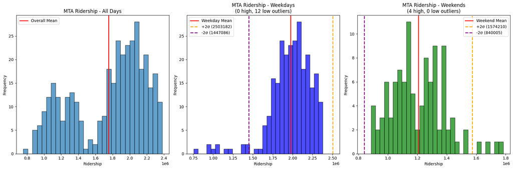

```
{Timestamp('2023-01-02 00:00:00'), Timestamp('2023-01-16 00:00:00'), Timestamp('2023-10-28 00:00:00'), Timestamp('2023-12-02 00:00:00'), Timestamp('2023-05-29 00:00:00'), Timestamp('2023-12-09 00:00:00'), Timestamp('2023-07-04 00:00:00'), Timestamp('2023-06-19 00:00:00'), Timestamp('2023-12-16 00:00…
```

```python
# Create histograms
# Set up the figure
fig, axes = plt.subplots(1, 3, figsize=(18, 6))

# Histogram for all days
axes[0].hist(mta_totals_df['ridership'], bins=30, edgecolor='black', alpha=0.7)
axes[0].axvline(mta_totals_df['ridership'].mean(), color='red', linestyle='-', linewidth=2, label='Overall Mean')
axes[0].set_title(f'MTA Ridership - All Days')
axes[0].set_xlabel('Ridership')
axes[0].set_ylabel('Frequency')
axes[0].legend()

# Histogram for weekdays with thresholds
axes[1].hist(weekday_data['ridership'], bins=30, edgecolor='black', alpha=0.7, color='blue')
axes[1].axvline(weekday_mean, color='red', linestyle='-', linewidth=2, label='Weekday Mean')
axes[1].axvline(weekday_upper_threshold, color='orange', linestyle='--', linewidth=2,
                label=f'+2σ ({weekday_upper_threshold:.0f})')
axes[1].axvline(weekday_lower_threshold, color='purple', linestyle='--', linewidth=2,
                label=f'-2σ ({weekday_lower_threshold:.0f})')
axes[1].set_title(f'MTA Ridership - Weekdays\n({len(weekday_upper_outliers)} high, {len(weekday_lower_outliers)} low outliers)')
axes[1].set_xlabel('Ridership')
axes[1].set_ylabel('Frequency')
axes[1].legend()

# Histogram for weekends with thresholds
axes[2].hist(weekend_data['ridership'], bins=30, edgecolor='black', alpha=0.7, color='green')
axes[2].axvline(weekend_mean, color='red', linestyle='-', linewidth=2, label='Weekend Mean')
axes[2].axvline(weekend_upper_threshold, color='orange', linestyle='--', linewidth=2,
                label=f'+2σ ({weekend_upper_threshold:.0f})')
axes[2].axvline(weekend_lower_threshold, color='purple', linestyle='--', linewidth=2,
                label=f'-2σ ({weekend_lower_threshold:.0f})')
axes[2].set_title(f'MTA Ridership - Weekends\n({len(weekend_upper_outliers)} high, {len(weekend_lower_outliers)} low outliers)')
axes[2].set_xlabel('Ridership')
axes[2].set_ylabel('Frequency')
axes[2].legend()

plt.tight_layout()
plt.show()

# Identify outlier dates to remove
outlier_dates = set()

# Add weekday outlier dates
outlier_dates.update(weekday_upper_outliers['date'].tolist())
outlier_dates.update(weekday_lower_outliers['date'].tolist())

# Add weekend outlier dates
outlier_dates.update(weekend_upper_outliers['date'].tolist())
outlier_dates.update(weekend_lower_outliers['date'].tolist())

print(outlier_dates)

# Remove outlier dates from the original dataframe
mta_clean = mta_df[~mta_df['date'].isin(outlier_dates)].copy()
mta_clean['day_of_week'] = mta_clean['date'].dt.day_name()
mta_clean['weekend'] = mta_clean['date'].dt.dayofweek.isin([5, 6])

# Reset index for cleanliness
mta_clean = mta_clean.reset_index(drop=True)

# Save to CSV
mta_clean.to_csv('data/02-processed/MTA_Ridership_cleaned.csv', index=False)
```

### Ride Hailing Dataset

Our dataset is provided by the NYC government, so it's publicly accessible, and contains transport data from Janurary 1st 2023 to Janurary 1st 2024 for high volume for hire vehicles. This includes services like Uber and Lyft. We chose this dataset because it aggregates all rideshare companies, and since their inception it takes up about 80% of the marketshare for ride-hailing services.

The dataset has lots of metrics, but the ones that we are going to apply to our project are the pickup date and time, the location ID (Taxi Zones), the distance traveled, the trip time, and a lot of the cost components like sales tax, base price, and additional fees. To clean the data, we aggregated the costs and combined the columns into a single total cost column. Our immediate goals don't necessitate these metrics, but we might use them for more analysis later on, so we placed it in the 01-interim folder temporarily. The dataset that we were provided was nearly perfect, and we did our due diligence checking for any abnormal behavior, but we concluded that it was fine as is, just needed to remove some columns.

Note that due to the rather large datasize, we were unable to upload it via the URL, so we manually uploaded the 80MB file ourselves. The cleaned interim data is about 30MB, but this is just for one day. To concatenate the data, I created a function that can aggregate the entries into rides per hour per each taxi zone. This now matches the hourly format of the MTA data, and is much more processable at 172KB. Converting each day to this format will prove challenging due to the limitations of the API, and the aforementioned large file sizes, but not impossible.

```python
ridehail_df = pd.read_csv("data/01-interim/TLC_ridehail/ridehailing_daily_ridership.csv")
print(ridehail_df.columns)
# Convert dates
ridehail_df['date'] = pd.to_datetime(ridehail_df['date'])

# Add day of week columns
ridehail_df['day_of_week'] = ridehail_df['date'].dt.day_name()

# Add weekend column (using dayofweek numbers: 5=Saturday, 6=Sunday)
ridehail_df['weekend'] = ridehail_df['date'].dt.dayofweek.isin([5, 6])
ridehail_total = ridehail_df.groupby('date', as_index=False)['trip_count'].sum()

# Split data into weekday and weekend
weekday_data = ridehail_df[~ridehail_df['weekend']]
weekend_data = ridehail_df[ridehail_df['weekend']]

# Aggregate to daily totals
weekday_total = weekday_data.groupby('date', as_index=False)['trip_count'].sum()
weekend_total = weekend_data.groupby('date', as_index=False)['trip_count'].sum()

# Merge back day_of_week for printing purposes
weekday_total = weekday_total.merge(weekday_data[['date', 'day_of_week']].drop_duplicates(), on='date', how='left')
weekend_total = weekend_total.merge(weekend_data[['date', 'day_of_week']].drop_duplicates(), on='date', how='left')

# Calculate statistics for weekdays
weekday_mean = weekday_total['trip_count'].mean()
weekday_std = weekday_total['trip_count'].std()
weekday_upper_threshold = weekday_mean + (3 * weekday_std)
weekday_lower_threshold = weekday_mean - (3 * weekday_std)
weekday_upper_outliers = weekday_total[weekday_total['trip_count'] > weekday_upper_threshold]
weekday_lower_outliers = weekday_total[weekday_total['trip_count'] < weekday_lower_threshold]

# Calculate statistics for weekends
weekend_mean = weekend_total['trip_count'].mean()
weekend_std = weekend_total['trip_count'].std()
weekend_upper_threshold = weekend_mean + (3 * weekend_std)
weekend_lower_threshold = weekend_mean - (3 * weekend_std)
weekend_upper_outliers = weekend_total[weekend_total['trip_count'] > weekend_upper_threshold]
weekend_lower_outliers = weekend_total[weekend_total['trip_count'] < weekend_lower_threshold]

# Print weekday outliers
print(f"\nWEEKDAY - HIGH OUTLIERS (above +3σ): {len(weekday_upper_outliers)} days found")
print("-" * 50)
if len(weekday_upper_outliers) > 0:
    for idx, row in weekday_upper_outliers.iterrows():
        print(f"Date: {row['date'].strftime('%Y-%m-%d')}, "
            f"trip_count: {row['trip_count']:.0f}, "
            f"Day: {row['day_of_week']} "
            f"(+{(row['trip_count'] - weekday_mean)/weekday_std:.2f}σ)")
else:
    print("No weekday high outliers found above +3σ")

print(f"\nWEEKDAY - LOW OUTLIERS (below -3σ): {len(weekday_lower_outliers)} days found")
print("-" * 50)
if len(weekday_lower_outliers) > 0:
    for idx, row in weekday_lower_outliers.iterrows():
        print(f"Date: {row['date'].strftime('%Y-%m-%d')}, "
            f"trip_count: {row['trip_count']:.0f}, "
            f"Day: {row['day_of_week']} "
            f"({(row['trip_count'] - weekday_mean)/weekday_std:.2f}σ)")
else:
    print("No weekday low outliers found below -3σ")

# Print weekend statistics
print(f"\nWeekend Statistics:")
print(f"Mean trip_count (Weekends): {weekend_mean:.2f}")
print(f"Standard deviation: {weekend_std:.2f}")
print(f"Upper 3-sigma threshold (+3σ): {weekend_upper_threshold:.2f}")
print(f"Lower 3-sigma threshold (-3σ): {weekend_lower_threshold:.2f}")

print(f"\nWEEKEND - HIGH OUTLIERS (above +3σ): {len(weekend_upper_outliers)} days found")
print("-" * 50)
if len(weekend_upper_outliers) > 0:
    for idx, row in weekend_upper_outliers.iterrows():
        print(f"Date: {row['date'].strftime('%Y-%m-%d')}, "
            f"trip_count: {row['trip_count']:.0f}, "
            f"Day: {row['day_of_week']} "
            f"(+{(row['trip_count'] - weekend_mean)/weekend_std:.2f}σ)")
else:
    print("No weekend high outliers found above +3σ")

print(f"\nWEEKEND - LOW OUTLIERS (below -3σ): {len(weekend_lower_outliers)} days found")
print("-" * 50)
if len(weekend_lower_outliers) > 0:
    for idx, row in weekend_lower_outliers.iterrows():
        print(f"Date: {row['date'].strftime('%Y-%m-%d')}, "
            f"trip_count: {row['trip_count']:.0f}, "
            f"Day: {row['day_of_week']} "
            f"({(row['trip_count'] - weekend_mean)/weekend_std:.2f}σ)")
else:
    print("No weekend low outliers found below -3σ")
```

```
Index(['date', 'PULocationID', 'trip_count'], dtype='str')

WEEKDAY - HIGH OUTLIERS (above +3σ): 0 days found
--------------------------------------------------
No weekday high outliers found above +3σ

WEEKDAY - LOW OUTLIERS (below -3σ): 1 days found
--------------------------------------------------
Date: 2023-01-02, trip_count: 479217, Day: Monday (-3.00σ)

Weekend Statistics:
Mean trip_count (Weekends): 809889.60
Standard deviation: 86286.58
Upper 3-sigma threshold (+3σ): 1068749.35
Lower 3-sigma threshold (-3σ): 551029.85

WEEKEND - HIGH OUTLIERS (above +3σ): 0 days found
--------------------------------------------------
No weekend high outliers found above +3σ

WEEKEND - LOW OUTLIERS (below -3σ): 0 days found
--------------------------------------------------
No weekend low outliers found below -3σ
```

### Weather Dataset

This dataset is key for avoiding incorrect analysis with weather as a confounding variable. The important metrics are the max, min, and average temperature (in fahrenheit), precipitation (in inches of rain), and snow (in inches of snow). These are important as inconvenient weather may be the difference between walking to a subway station or paying a premium to hail a taxi or uber. Additionally, rain could decrease subway ridership through less desired conditions, such as humidity, dampness, or smell, while snow could also affect ridership in both modes of transportation.

Major concerns for this dataset are primarily around the amount of missing values or NaNs. Additionally some columns are of mixed data type and need to be cleaned.

```python
#import pandas as pd
#import numpy as np
#load the dataset
df_w = pd.read_csv("data/00-raw/NYC2023Weather.csv")
#print size of data set
print('The size of weather data is:',len(df_w))
```

```
The size of weather data is: 33284
```

```python
#missing data
print('Number of N/A data:', df_w.isna().sum(axis=1).sum())
print('Number of missing data per column:',df_w.isna().sum(axis=0))
```

```
Number of N/A data: 485512
Number of missing data per column: STATION          0
NAME             0
LATITUDE         0
LONGITUDE        0
ELEVATION        0
DATE             0
DAPR         32700
MDPR         32704
PRCP           779
SNOW         11522
SNWD         24336
TAVG         32189
TMAX         27747
TMIN         27745
TOBS         30817
WT01         32536
WT02         33225
WT03         33044
WT04         33256
WT05         33282
WT06         33284
WT08         33073
WT11         33273
dtype: int64
```

```python
#most of missing data is in variables we do not need
#how many stations have all the data we need?
df_w_na = df_w.dropna(subset = ['STATION','NAME','LONGITUDE','LATITUDE','DATE','TMAX','TMIN', 'PRCP','SNOW'])
print('Number of valid stations:', len(df_w_na['NAME'].unique()), ', more than enough!')
```

```
Number of valid stations: 11 , more than enough!
```

```python
## make the dataset tidy
#trim unnecessary data and rename columns
rename_map = {'STATION': 'Station', 'NAME': 'Name', 'LATITUDE': 'Latitude', 'LONGITUDE': 'Longitude', 'DATE': 'Date', 'PRCP': 'Precipitation', 'SNOW': 'Snow', 'TAVG': 'Avg_Temp', 'TMAX': 'Max_Temp', 'TMIN': 'Min_Temp'}
col_keep = ['STATION', 'NAME', 'LATITUDE', 'LONGITUDE', 'DATE', 'PRCP', 'SNOW', 'TAVG', 'TMAX', 'TMIN']

df_w = df_w[col_keep].rename(columns = rename_map)
df_w.head()

df_w = df_w.dropna(subset = ['Station','Name','Latitude','Longitude','Date','Max_Temp','Min_Temp', 'Precipitation','Snow'])

#categorize snow and rainy days in new column (boolean)
df_w['Rain?'] = np.where(df_w['Precipitation'] > 0, 'yes', 'no')
df_w['Snow?'] = np.where(df_w['Snow'] > 0, 'yes', 'no')

#indexing fix
df_w = df_w.reset_index(drop = True)

#some days are missing average values, let's assume the mean of Max_Temp and Min_Temp is Avg_Temp for those days only
temp_means = (df_w['Max_Temp'] + df_w['Min_Temp']) / 2
df_w['Avg_Temp'] = df_w['Avg_Temp'].fillna(temp_means)

#make sure all dates are in proper format and convert to date time
df_w['Date'] = pd.to_datetime(df_w['Date'])

# split dataset by state
df_ny_w = df_w[df_w['Name'].str.contains('NY')]
df_nj_w = df_w[df_w['Name'].str.contains('NJ')]

#narrow down to manhattan, using Central Park station data
df_central_park = df_ny_w[df_ny_w['Name'] == 'NY CITY CENTRAL PARK, NY US']
#another indexing fix
df_central_park = df_central_park.reset_index(drop = True)
```

```python
#check for inconsistencies (unhash for more info)
#df_central_park[['Precipitation','Snow', 'Avg_Temp', 'Max_Temp', 'Min_Temp']].describe()
print('Minimum recorded temperature:',df_central_park['Min_Temp'].min(), 'Farenheight')
print('Day of minimum temperature (index, date):', df_central_park['Date'].loc[df_central_park['Min_Temp'] == df_central_park['Min_Temp'].min()])
print('According to Google, 2/4/23-2/5/23 had extreme lows of around 3°F. May be a potential future outlier.')
```

```
Minimum recorded temperature: 3.0 Farenheight
Day of minimum temperature (index, date): 34   2023-02-04
Name: Date, dtype: datetime64[us]
According to Google, 2/4/23-2/5/23 had extreme lows of around 3°F. May be a potential future outlier.
```

```python
#save to data/02-processed (unhash to save)
#df_central_park.to_csv('data/02-processed/CLEANED_CentralPark_Weather2023.csv', index = False)
#df_ny_w.to_csv('data/02-processed/CLEANED_NewYork_Weather2023.csv', index = False)
#df_nj_w.to_csv('data/02-processed/CLEANED_NewJersey_Weather2023.csv', index = False)
```

### Gas Price Dataset

The organization that published this dataset is the U.S. Energy Information Administration (EIA) which is an independent federal statistical agency that collects, analyzes, and disseminates independent and impartial energy information. This specific dataset contains weekly average retail prices for regular gasoline in the New York City area in dollars per gallon. The dataset has two variables: the week-ending date and the average retail price in USD per gallon. It covers data from 2000 to present year which means there are approximately 1,340 weekly observations. The prices that consumers pay range from a little more than a dollar to nearly five dollars per gallon.

The data reveals major price spikes that coincide with significant events, such as Hurricane Katrina, which hit oil-producing regions and caused a spike in prices. In 2008, oil prices were at an all-time high that could be attributed to financial speculation and coinciding with the US being amidst a great recession. The peak of 2022 can be suggested to be due to the post pandemic activities that occur after things start opening up after a shutdown. Overall, lower prices under 3.00 dollars per gallon tend to correspond with periods of economic downs while prices above 4.00 dollars per gallon indicate increasing global demands.

(https://www.ebsco.com/research-starters/economics/2000s-oil-crisis)

(https://www.energy.gov/articles/what-eia-and-what-does-it-do#:~:text=The%20Energy%20Information%20Administration%20(EIA,the%20economy%20and%20the%20environment.)

```python
# import pandas as pd

# Reads fuel price data
gas_raw = pd.read_csv('data/00-raw/Weekly_Gas_Prices.csv')
# drop extra columns generated by conversion XLS -> CSV
gas_raw = gas_raw.drop(gas_raw.columns[2:5], axis=1)
# Created data column
gas_raw['Date'] = pd.to_datetime(gas_raw['Date'])
# Filtered to just 2023
gas_2023 = gas_raw[(gas_raw['Date'] >= '2023-01-01') & (gas_raw['Date'] <= '2023-12-31')].copy()
# Renamed column
gas_2023 = gas_2023.rename(columns={gas_2023.columns[1]: 'gas_price_dollars_per_gallon'})
# Create csv of weekly prices
# gas_2023.to_csv('data/02-processed/nyc_gas_prices_weekly_2023.csv', index=False)
# Fill daily for each week
gas_daily_2023 = gas_2023.set_index('Date').resample('D').ffill().reset_index()
# Create csv of weekly prices
# gas_daily_2023.to_csv('data/02-processed/nyc_gas_prices_daily_2023.csv', index=False)
```

## Results

### Exploratory Data Analysis

#### Section 1 of EDA - Ridehailing vs MTA ridership analysis

```python
import pandas as pd
import numpy as np
import matplotlib.pyplot as plt
import seaborn as sns
import geopandas as gpd
from shapely.geometry import Point, box
from shapely.ops import unary_union
from datetime import datetime
from modules import graph, utils, maps

subway_stations_gdf, taxi_zones_gdf, subway_lines_gdf = utils.prepare_gdf_data()
ridehail_df, mta_df = utils.prepare_ridership_data('data/02-processed/ridehailing_daily_cleaned.csv','data/02-processed/MTA_Ridership_cleaned.csv')
```

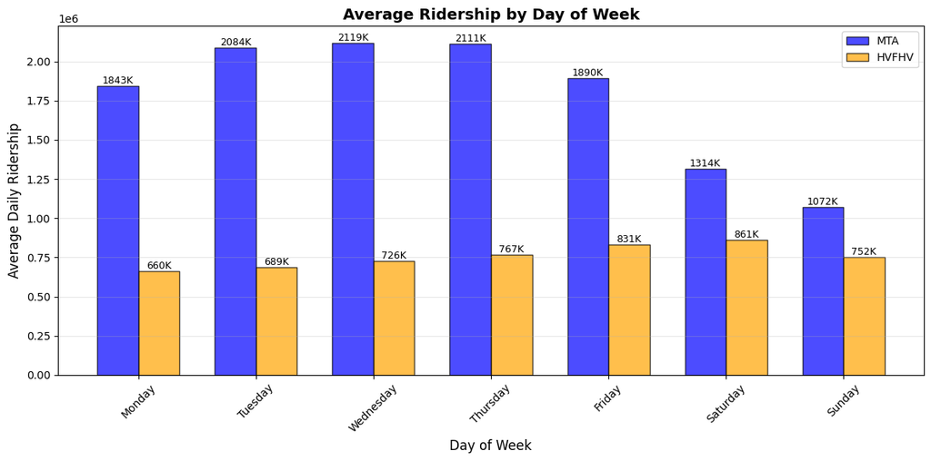

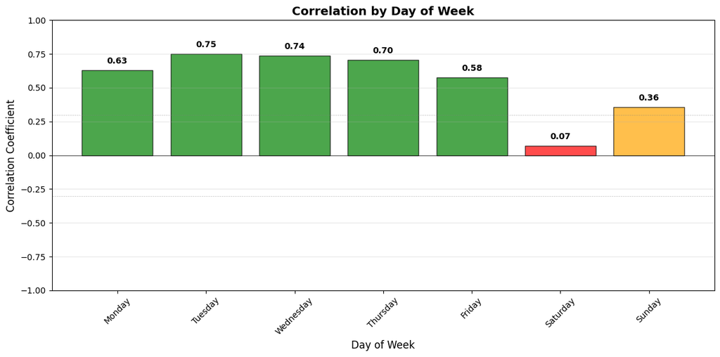

```python
from modules import graph
ridehail_df, mta_df = utils.prepare_ridership_data('data/02-processed/ridehailing_daily_cleaned.csv','data/02-processed/MTA_Ridership_cleaned.csv')
#print(ridehail_df.columns)

graph.plot_ridership_histogram(mta_df, ridehail_df)
```

From this histogram we can observe that the MTA sees a sharp decrease in ridership over the weekend on average, whereas ridehailing services increase over the weekend indicating that there might be a negative correlation.

From the correlation by day graph, we observe that there are moderate-strong levels of correlation throughout each weekday, but the correlation drops significantly on the weekend

```
======================================================================
PLOT 1: Daily Time Series Comparison
======================================================================
```

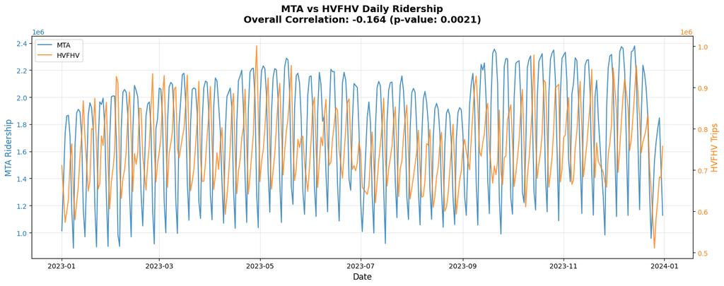

```
📊 Daily Time Series Analysis:
==================================================
Overall Pearson correlation: -0.1643
P-value: 0.0021
Significance: ** (p < 0.01)

======================================================================
PLOT 2: Rolling Correlation (30-day window)
======================================================================
```

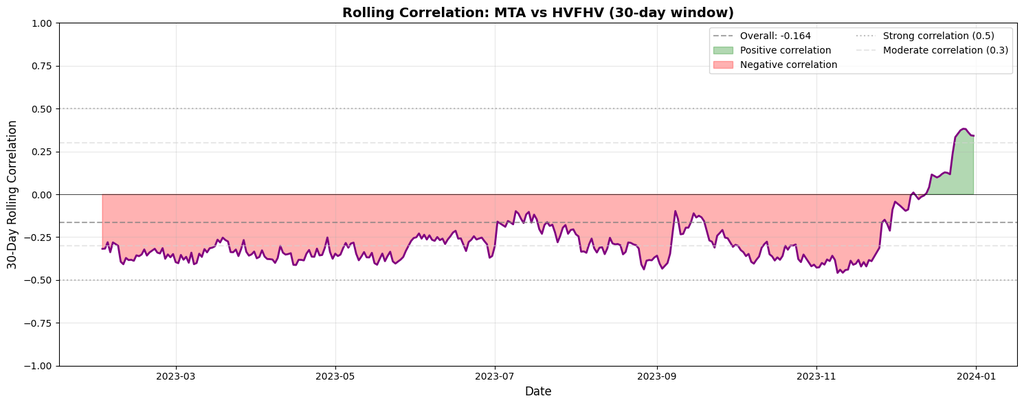

```
📊 Rolling Correlation Analysis (30-day window):
==================================================
Rolling correlation statistics:
  - Mean: -0.2743
  - Std: 0.1496
  - Min: -0.4587
  - Max: 0.3822
  - % time positive: 5.2%
  - % time strong (>0.5): 0.0%
```

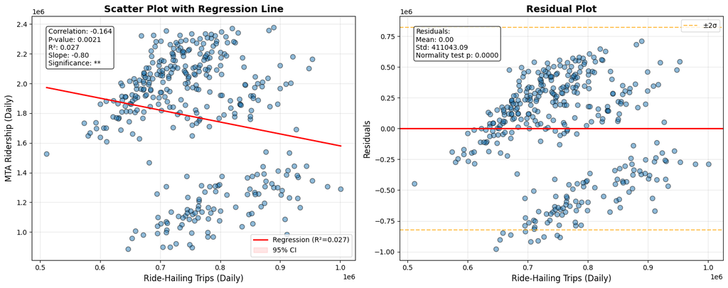

```
📊 Detailed Correlation Analysis:
==================================================
Pearson correlation coefficient: -0.1643
P-value: 0.0021
R-squared: 0.0270

Regression equation: MTA = -0.80 × HVFHV + 2383789.26
Standard error: 0.2591

Significance level:
  ** p < 0.01 (Very significant)

Residual analysis:
  Mean: 0.0000 (should be close to 0)
  Standard deviation: 411043.0934
  Normality test p-value: 0.0000
```

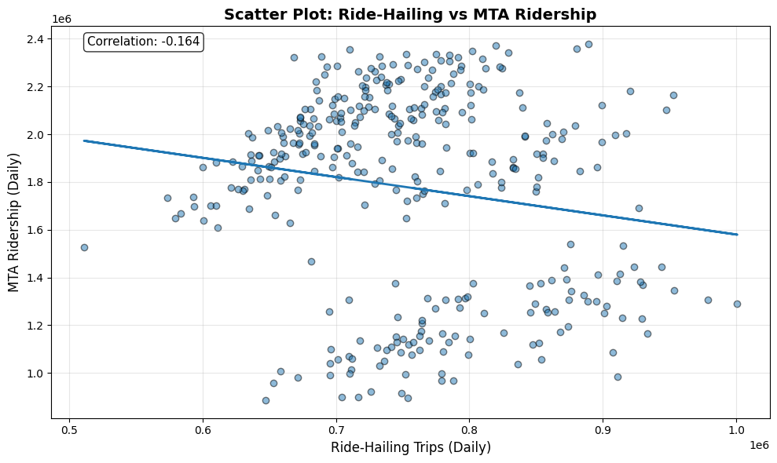

```
📊 Correlation between ride-hailing and MTA ridership: -0.164
```

```python
graph.plot_mta_vs_ridehail_both(mta_df, ridehail_df)
scatterplot = graph.scatterplot_mta_vs_ridehail_daily(mta_df, ridehail_df)
```

Let's seperate weekday and weekend and see if we can find any correlation

```
Weekday MTA vs Ridehail
======================================================================
PLOT 1: Daily Time Series Comparison
======================================================================
```

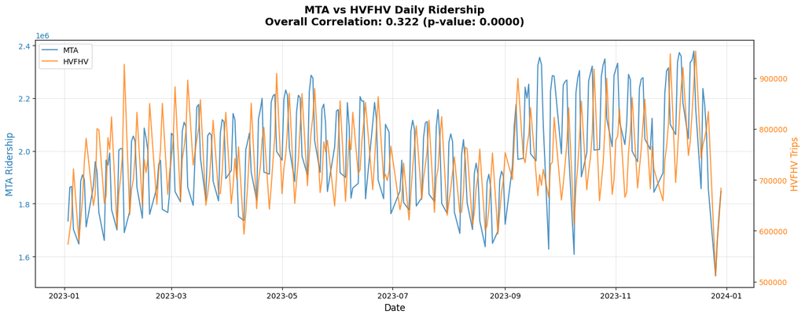

```
📊 Daily Time Series Analysis:
==================================================
Overall Pearson correlation: 0.3221
P-value: 0.0000
Significance: *** (p < 0.001)

======================================================================
PLOT 2: Rolling Correlation (30-day window)
======================================================================
```

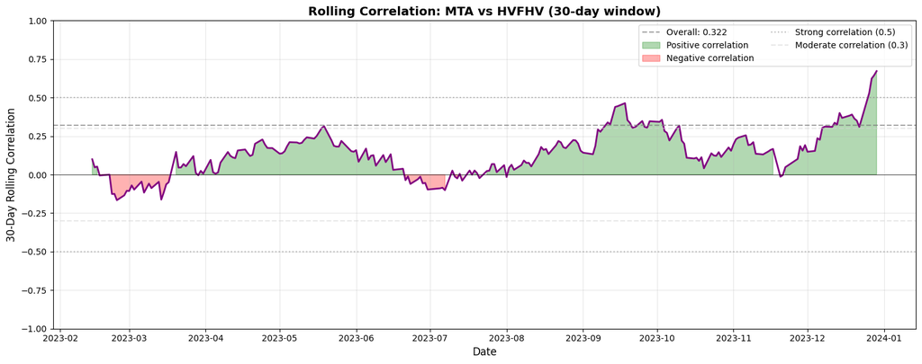

```
📊 Rolling Correlation Analysis (30-day window):
==================================================
Rolling correlation statistics:
  - Mean: 0.1397
  - Std: 0.1486
  - Min: -0.1659
  - Max: 0.6720
  - % time positive: 72.2%
  - % time strong (>0.5): 1.6%
```

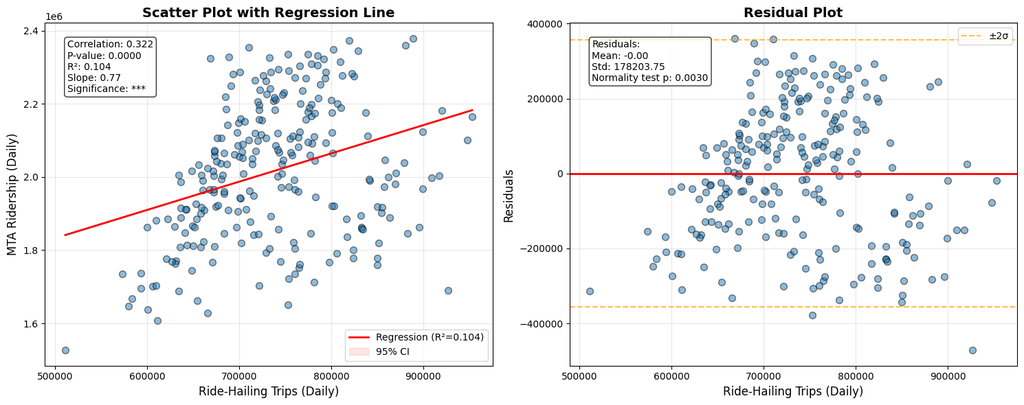

```
📊 Detailed Correlation Analysis:
==================================================
Pearson correlation coefficient: 0.3221
P-value: 0.0000
R-squared: 0.1037

Regression equation: MTA = 0.77 × HVFHV + 1446520.82
Standard error: 0.1447

Significance level:
  *** p < 0.001 (Highly significant)

Residual analysis:
  Mean: -0.0000 (should be close to 0)
  Standard deviation: 178203.7519
  Normality test p-value: 0.0030
```

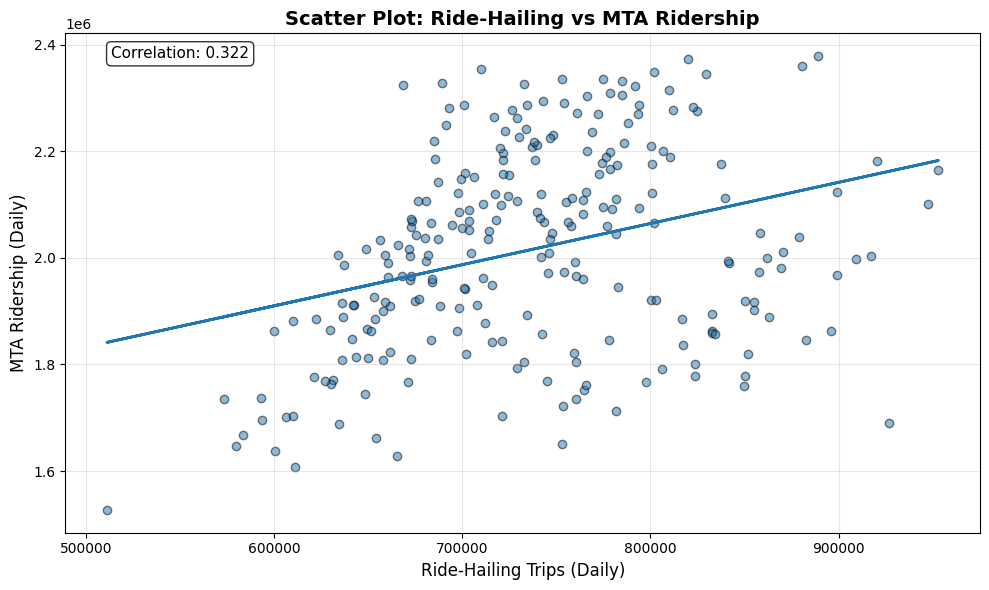

```
📊 Correlation between ride-hailing and MTA ridership: 0.322
Weekend MTA vs Ridehail
======================================================================
PLOT 1: Daily Time Series Comparison
======================================================================
```

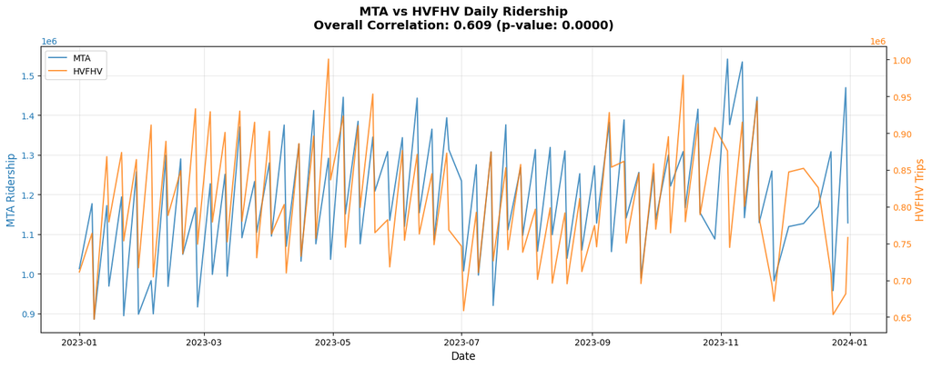

```
📊 Daily Time Series Analysis:
==================================================
Overall Pearson correlation: 0.6087
P-value: 0.0000
Significance: *** (p < 0.001)

======================================================================
PLOT 2: Rolling Correlation (30-day window)
======================================================================
```

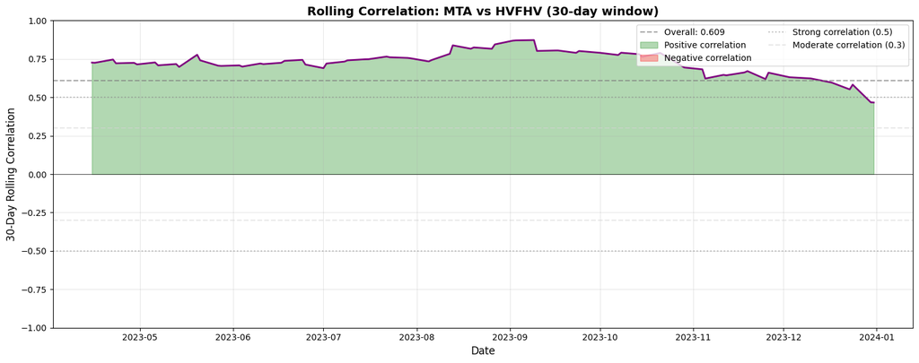

```
📊 Rolling Correlation Analysis (30-day window):
==================================================
Rolling correlation statistics:
  - Mean: 0.7279
  - Std: 0.0804
  - Min: 0.4661
  - Max: 0.8728
  - % time positive: 71.3%
  - % time strong (>0.5): 69.3%
```

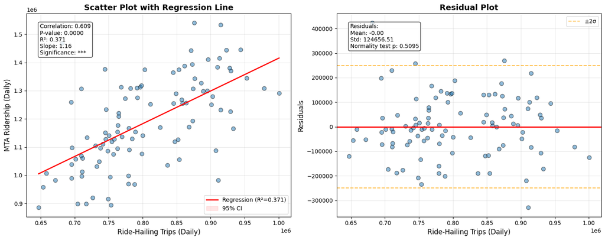

```
📊 Detailed Correlation Analysis:
==================================================
Pearson correlation coefficient: 0.6087
P-value: 0.0000
R-squared: 0.3705

Regression equation: MTA = 1.16 × HVFHV + 253527.25
Standard error: 0.1522

Significance level:
  *** p < 0.001 (Highly significant)

Residual analysis:
  Mean: -0.0000 (should be close to 0)
  Standard deviation: 124656.5143
  Normality test p-value: 0.5095
```

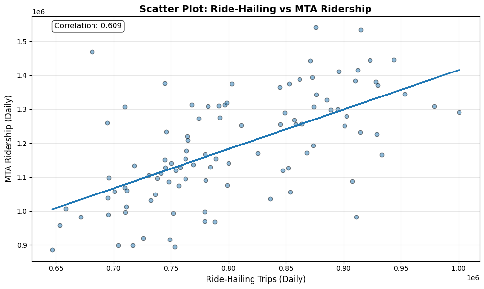

```
📊 Correlation between ride-hailing and MTA ridership: 0.609
```

```python
mta_df_weekday = mta_df[mta_df['weekend'] ==False]
ridehail_df_weekday = ridehail_df[ridehail_df['weekend'] == False]

mta_df_weekend = mta_df[mta_df['weekend'] ==True]
ridehail_df_weekend =ridehail_df[ridehail_df['weekend'] == True]

print('Weekday MTA vs Ridehail')
graph.plot_mta_vs_ridehail_both(mta_df_weekday, ridehail_df_weekday)
graph.scatterplot_mta_vs_ridehail_daily(mta_df_weekday, ridehail_df_weekday)
print('Weekend MTA vs Ridehail')
graph.plot_mta_vs_ridehail_both(mta_df_weekend, ridehail_df_weekend)
graph.scatterplot_mta_vs_ridehail_daily(mta_df_weekend, ridehail_df_weekend)
```

## Zonal Analysis

```python
from modules import maps


ridehail_df['PULocationID'] = ridehail_df['PULocationID'].astype(str)
taxi_zones_gdf['locationid'] = taxi_zones_gdf['locationid'].astype(str)

weekday_df = ridehail_df[ridehail_df['weekend'] == 0]
weekend_df = ridehail_df[ridehail_df['weekend'] == 1]

weekday_avg = weekday_df.groupby('PULocationID')['trip_count'].mean().reset_index()
weekend_avg = weekend_df.groupby('PULocationID')['trip_count'].mean().reset_index()
weekday_avg.columns = ['PULocationID', 'avg_trip_count']
weekend_avg.columns = ['PULocationID', 'avg_trip_count']

zones_weekday = taxi_zones_gdf.merge(weekday_avg, left_on='locationid', right_on='PULocationID', how='left')
zones_weekday['avg_trip_count'] = zones_weekday['avg_trip_count'].fillna(0)
manhattan = zones_weekday[zones_weekday['borough'] == 'Manhattan']

print(f"\n Weekday Ridehail- Manhattan Summary:")
print(f"Total avg trips: {manhattan['avg_trip_count'].sum():,.0f}")
print("\nTop 5 zones:")
top = manhattan.nlargest(5, 'avg_trip_count')[['zone', 'avg_trip_count']]
for idx, row in top.iterrows():
    print(f"  {row['zone']}: {row['avg_trip_count']:,.0f} avg trips")


zones_weekend = taxi_zones_gdf.merge(weekend_avg, left_on='locationid', right_on='PULocationID', how='left')
zones_weekend['avg_trip_count'] = zones_weekend['avg_trip_count'].fillna(0)
manhattan = zones_weekend[zones_weekend['borough'] == 'Manhattan']

print(f"\n Weekend Ridehail- Manhattan Summary:")
print(f"Total avg trips: {manhattan['avg_trip_count'].sum():,.0f}")
print("\nTop 5 zones:")
top = manhattan.nlargest(5, 'avg_trip_count')[['zone', 'avg_trip_count']]
for idx, row in top.iterrows():
    print(f"  {row['zone']}: {row['avg_trip_count']:,.0f} avg trips")

#maps.plot_ridehail_heatmap_by_day(ridehail_df, taxi_zones_gdf, 1, 20000, False)
#maps.plot_ridehail_heatmap_by_day(ridehail_df, taxi_zones_gdf, 2, 20000, False)
#maps.plot_ridehail_heatmap_by_day(ridehail_df, taxi_zones_gdf, 3, 20000, False)
#maps.plot_ridehail_heatmap_by_day(ridehail_df, taxi_zones_gdf, 4, 20000, False)
#maps.plot_ridehail_heatmap_by_day(ridehail_df, taxi_zones_gdf, 5, 20000, False)
#maps.plot_ridehail_heatmap_by_day(ridehail_df, taxi_zones_gdf, 6, 20000, False)
#maps.plot_ridehail_heatmap_by_day(ridehail_df, taxi_zones_gdf, 7, 20000, False)
```

[output not shown]

Above we've identified the Top Zones for Ridehailing Journeys

| Weekday | Weekend |
| --- | --- |
| Midtown Center: 14,503 avg trips | East Village: 17,234 avg trips |
| Times Sq/Theatre District: 11,779 avg trips | Lower East Side: 12,607 avg trips |
| Upper East Side South: 11,150 avg trips | West Village: 11,649 avg trips |
| Midtown East: 10,025 avg trips | Clinton East: 11,273 avg trips |
| Upper East Side North: 9,964 avg trips | Times Sq/Theatre District: 11,106 avg trips |

```python
from modules import maps, utils

# Load the data
subway_stations_gdf, taxi_zones_gdf, subway_lines_gdf = utils.prepare_gdf_data()
ridehail_df, mta_df = utils.prepare_ridership_data(
    'data/02-processed/ridehailing_daily_cleaned.csv',
    'data/02-processed/MTA_Ridership_cleaned.csv'
)

# ============================================
# MAP SUBWAY STATIONS TO TAXI ZONES (same as heatmap function)
# ============================================

# Make a copy and ensure CRS
stations_gdf = subway_stations_gdf.copy()
if stations_gdf.crs is None:
    stations_gdf = stations_gdf.set_crs('EPSG:4326')

# Convert to projected CRS for buffering
stations_gdf = stations_gdf.to_crs('EPSG:3857')
taxi_zones_proj = taxi_zones_gdf.to_crs('EPSG:3857')

# Create buffers (0.1 miles - same as heatmap)
buffer_miles = 0.1
buffer_meters = buffer_miles * 1609.34
stations_gdf['buffer_geom'] = stations_gdf.geometry.buffer(buffer_meters)

# Spatial join using buffers
stations_buffer = stations_gdf[['Complex ID', 'Stop Name', 'Borough']].copy()
stations_buffer = stations_buffer.set_geometry(stations_gdf['buffer_geom'])
stations_buffer.crs = stations_gdf.crs

station_zone_mapping = gpd.sjoin(
    stations_buffer,
    taxi_zones_proj,
    how='left',
    predicate='intersects'
)

# Remove duplicates
station_zone_mapping = station_zone_mapping.drop_duplicates(subset=['Complex ID', 'locationid'])

# Prepare MTA data
mta_df['date'] = pd.to_datetime(mta_df['date'])
mta_df['station_complex_id'] = mta_df['station_complex_id'].astype(str)
station_zone_mapping['Complex ID'] = station_zone_mapping['Complex ID'].astype(str)
station_zone_mapping['locationid'] = station_zone_mapping['locationid'].astype(str)
taxi_zones_gdf['locationid'] = taxi_zones_gdf['locationid'].astype(str)

# ============================================
# MTA ANALYSIS BY TAXI ZONE
# ============================================

# Merge ridership with zone mapping for all data
mta_with_zones = station_zone_mapping.merge(
    mta_df,
    left_on='Complex ID',
    right_on='station_complex_id',
    how='left'
)

# Calculate average ridership by taxi zone for weekdays/weekends
weekday_mta_zones = mta_with_zones[mta_with_zones['weekend'] == 0].groupby('locationid').agg({
    'ridership': 'mean'
}).reset_index()

weekend_mta_zones = mta_with_zones[mta_with_zones['weekend'] == 1].groupby('locationid').agg({
    'ridership': 'mean'
}).reset_index()

weekday_mta_zones.columns = ['locationid', 'avg_ridership']
weekend_mta_zones.columns = ['locationid', 'avg_ridership']

# Merge with taxi zones
zones_weekday = taxi_zones_gdf.merge(weekday_mta_zones, on='locationid', how='left')
zones_weekday['avg_ridership'] = zones_weekday['avg_ridership'].fillna(0)
manhattan_weekday = zones_weekday[zones_weekday['borough'] == 'Manhattan']

print(f"\n weekday - MTA Manhattan Summary (by taxi zone):")
print(f"Total avg ridership: {manhattan_weekday['avg_ridership'].sum():,.0f}")
print("\nTop 5 zones:")
top = manhattan_weekday.nlargest(5, 'avg_ridership')[['zone', 'avg_ridership']]
for idx, row in top.iterrows():
    print(f"  {row['zone']}: {row['avg_ridership']:,.0f} avg riders")

zones_weekend = taxi_zones_gdf.merge(weekend_mta_zones, on='locationid', how='left')
zones_weekend['avg_ridership'] = zones_weekend['avg_ridership'].fillna(0)
manhattan_weekend = zones_weekend[zones_weekend['borough'] == 'Manhattan']

print(f"\n weekend - MTA Manhattan Summary (by taxi zone):")
print(f"Total avg ridership: {manhattan_weekend['avg_ridership'].sum():,.0f}")
print("\nTop 5 zones:")
top = manhattan_weekend.nlargest(5, 'avg_ridership')[['zone', 'avg_ridership']]
for idx, row in top.iterrows():
    print(f"  {row['zone']}: {row['avg_ridership']:,.0f} avg riders")

# Calculate percent change
weekday_total = manhattan_weekday['avg_ridership'].sum()
weekend_total = manhattan_weekend['avg_ridership'].sum()
pct_change = ((weekend_total - weekday_total) / weekday_total) * 100
print(f"\n📈 MTA Weekend vs Weekday change (by zone): {pct_change:+.1f}%")

# Uncomment if you want to generate heatmaps
# maps.plot_subway_heatmap_by_day(mta_df, subway_stations_gdf, taxi_zones_gdf, 1, 75000, False)
# maps.plot_subway_heatmap_by_day(mta_df, subway_stations_gdf, taxi_zones_gdf, 2, 75000, False)
# maps.plot_subway_heatmap_by_day(mta_df, subway_stations_gdf, taxi_zones_gdf, 3, 75000, False)
# maps.plot_subway_heatmap_by_day(mta_df, subway_stations_gdf, taxi_zones_gdf, 4, 75000, False)
# maps.plot_subway_heatmap_by_day(mta_df, subway_stations_gdf, taxi_zones_gdf, 5, 75000, False)
# maps.plot_subway_heatmap_by_day(mta_df, subway_stations_gdf, taxi_zones_gdf, 6, 75000, False)
# maps.plot_subway_heatmap_by_day(mta_df, subway_stations_gdf, taxi_zones_gdf, 7, 75000, False)
```

```
 weekday - MTA Manhattan Summary (by taxi zone):
Total avg ridership: 1,200,115

Top 5 zones:
  Garment District: 68,604 avg riders
  Clinton East: 65,275 avg riders
  Midtown East: 59,156 avg riders
  Seaport: 58,126 avg riders
  Penn Station/Madison Sq West: 46,142 avg riders

 weekend - MTA Manhattan Summary (by taxi zone):
Total avg ridership: 709,363

Top 5 zones:
  Clinton East: 43,399 avg riders
  Garment District: 42,288 avg riders
  Seaport: 29,213 avg riders
  Penn Station/Madison Sq West: 28,200 avg riders
  Midtown East: 27,126 avg riders

📈 MTA Weekend vs Weekday change (by zone): -40.9%
```

Above we've identified the top zones for the weekday and weekend

| Weekday | Weekend |
| --- | --- |
| Garment District: 68,604 avg riders | Clinton East: 43,399 avg riders |
| Clinton East: 65,275 avg riders | Garment District: 42,288 avg riders |
| Midtown East: 59,156 avg riders | Seaport: 29,213 avg riders |
| Seaport: 58,126 avg riders | Penn Station/Madison Sq West: 28,200 avg riders |
| Penn Station/Madison Sq West: 46,142 avg riders | Midtown East: 27,126 avg riders |

As we can see The most popular stations are the same.

Below are the days of the week.

[figure not shown]

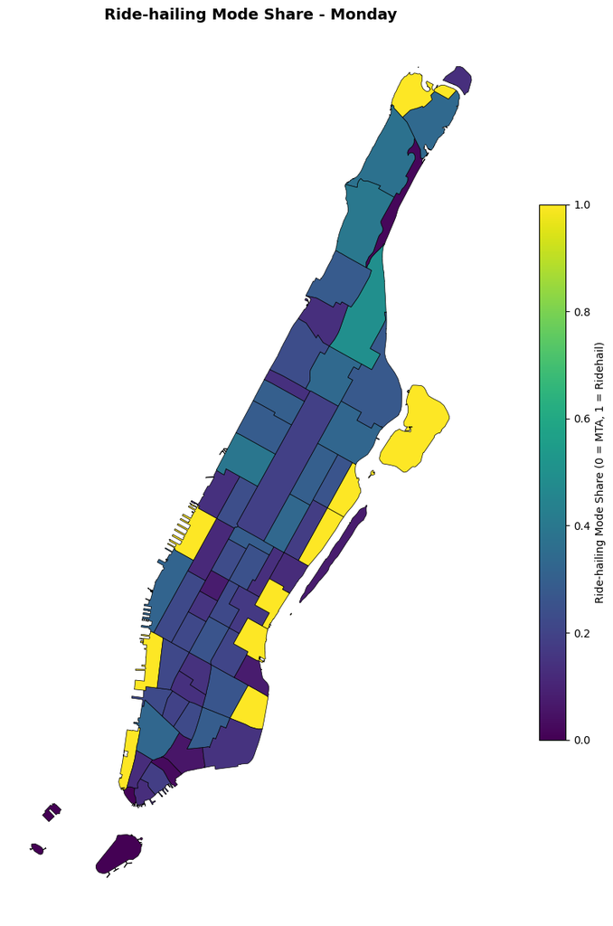

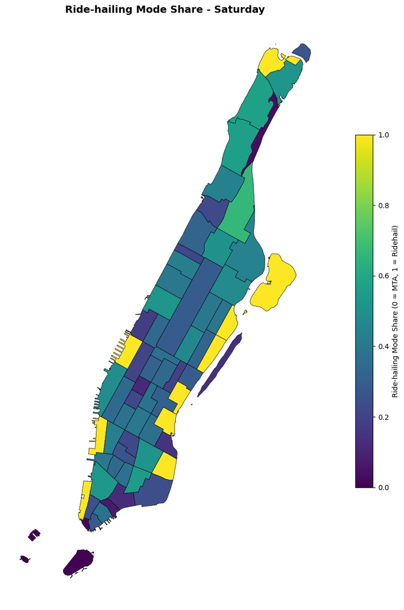

```python
modal = maps.plot_mode_share_heatmap_by_day(ridehail_df, mta_df, subway_stations_gdf, taxi_zones_gdf, 1)
modal = maps.plot_mode_share_heatmap_by_day(ridehail_df, mta_df, subway_stations_gdf, taxi_zones_gdf, 6)
```